# DS Minor: Lab 02 – Centrality measures and community detection Intro

## Описание сети

Первый этап анализа сетей (а иногда и единственный) – это описание сети, выделение важных элементов этой сети и выделение групп (сообществ) в сети на основании тесноты связей. Такое описание позволяет сформировать представление о структуре сети, описать какие-то общие закономерности, обусловленные связями.

### Меры центральности

Не все вершины в сети однаково важны – какие-то могут быть более влиятельны, какие-то менее. В разных задачах “важность” может пониматься по-разному.

Например, можно считать в сети друзей важнее того из них, у кого больше друзей (“чем больше связей, тем лучше”). Такой показатель называется **степенью (degree)**.

Рассмотрим на небольшом примере социальной сети - сети клуба карате (Zachary carate club).

Загрузим данные из пакета igraphdata (здесь цвет – вручную заданные группы)

```r
library(igraph)
library(igraphdata)

data(karate) # loading network from package
```

Посчитаем степень узла

```r
V(karate)
```

```
## + 34/34 vertices, named, from 4b458a1:
##  [1] Mr Hi    Actor 2  Actor 3  Actor 4  Actor 5  Actor 6  Actor 7  Actor 8
##  [9] Actor 9  Actor 10 Actor 11 Actor 12 Actor 13 Actor 14 Actor 15 Actor 16
## [17] Actor 17 Actor 18 Actor 19 Actor 20 Actor 21 Actor 22 Actor 23 Actor 24
## [25] Actor 25 Actor 26 Actor 27 Actor 28 Actor 29 Actor 30 Actor 31 Actor 32
## [33] Actor 33 John A
```

```r
degree(karate)
```

```
##    Mr Hi  Actor 2  Actor 3  Actor 4  Actor 5  Actor 6  Actor 7  Actor 8
##       16        9       10        6        3        4        4        4
##  Actor 9 Actor 10 Actor 11 Actor 12 Actor 13 Actor 14 Actor 15 Actor 16
##        5        2        3        1        2        5        2        2
## Actor 17 Actor 18 Actor 19 Actor 20 Actor 21 Actor 22 Actor 23 Actor 24
##        2        2        2        3        2        2        2        5
## Actor 25 Actor 26 Actor 27 Actor 28 Actor 29 Actor 30 Actor 31 Actor 32
##        3        3        2        4        3        4        4        6
## Actor 33   John A
##       12       17
```

Мы можем задать размер вершин графа таким образом, чтобы они соответствовали степени этих вершин, т.е. чем больше степень, тем больше вершина (коэффициенты не несут особого смысла, просто подобраны так, чтобы график был читаемым – если сделать вершину слишком большой, она перекроет собой все остальные, слишком маленькой – и разницы между вершинами будет не заметно)

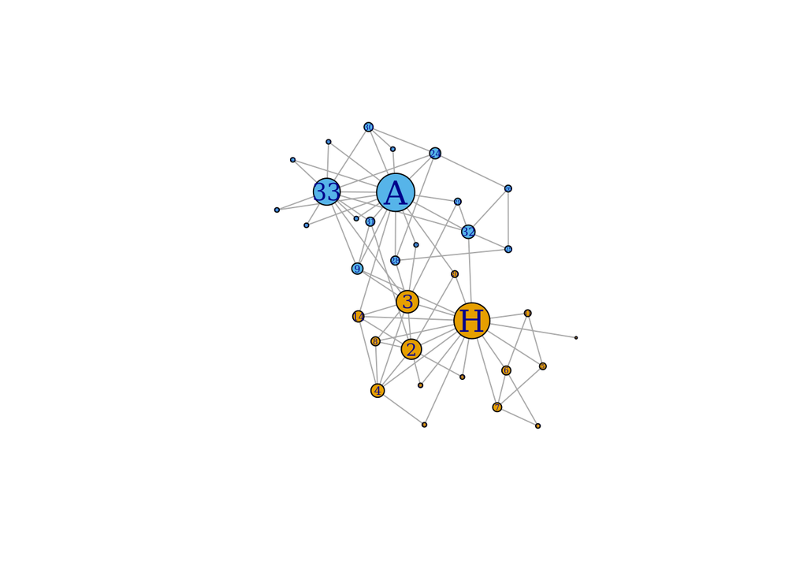

```r
plot(karate,
     vertex.size = degree(karate)*1.5,
     vertex.label.cex = degree(karate)/10,
     layout = layout.davidson.harel)
```

Еще одним показателем важности является **центральность по посредничеству, битвинность (betweenness)**. В этом случае важны вершины, которые являются посредниками между группами, находятся на “выгодном” месте.

Формально: Центральность по посредничеству характеризует долю кратчайших путей проходящих через данную вершину.
$$g(v)= \sum_{s \neq v \neq t}\frac{\sigma_{st}(v)}{\sigma_{st}},$$
где $\sigma_{st}$ – число кратчайших путей между $s$ и $t$, $\sigma_{st}(v)$ – число таких путей проходящих через $v$.

Вычисление (вот почему полезно знать название разных мер центральности на английском):

```r
betweenness(karate)
```

```
##      Mr Hi    Actor 2    Actor 3    Actor 4    Actor 5    Actor 6    Actor 7
## 250.150000  33.800000  36.650000   1.333333   0.500000  15.500000  15.500000
##    Actor 8    Actor 9   Actor 10   Actor 11   Actor 12   Actor 13   Actor 14
##   0.000000  13.100000   7.283333   0.500000   0.000000   0.000000   1.200000
##   Actor 15   Actor 16   Actor 17   Actor 18   Actor 19   Actor 20   Actor 21
##   0.000000   0.000000   0.000000  16.100000   3.000000 127.066667   0.000000
##   Actor 22   Actor 23   Actor 24   Actor 25   Actor 26   Actor 27   Actor 28
##   0.000000   0.000000   1.000000  33.833333   0.500000   0.000000   6.500000
##   Actor 29   Actor 30   Actor 31   Actor 32   Actor 33     John A
##  10.100000   0.000000   3.000000  66.333333  38.133333 209.500000
```

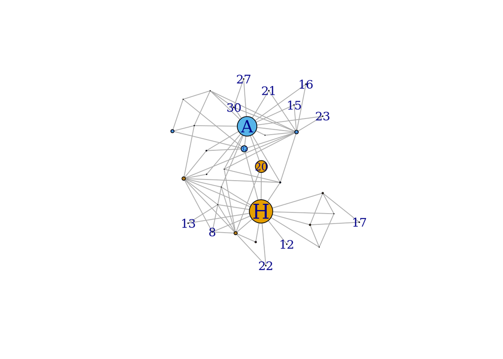

```r
plot(karate,
     vertex.size = betweenness(karate)/10,
     vertex.label.cex = betweenness(karate)/150,
     layout = layout.davidson.harel)
```

Если нам интересны вершины с наиболее короткими путями до остальных (т.е. наиболее близкие к остальным), то рассматривается **центральность по близости (closeness)**.

Формально: Центральность по близости обратно пропорциональна среднему расстоянию:
$$C(x)= \frac{N-1}{\sum_y d(y,x)}$$

```r
closeness(karate)
```

```
##       Mr Hi     Actor 2     Actor 3     Actor 4     Actor 5     Actor 6
## 0.007575758 0.005494505 0.005847953 0.005235602 0.004587156 0.004587156
##     Actor 7     Actor 8     Actor 9    Actor 10    Actor 11    Actor 12
## 0.004629630 0.005494505 0.005882353 0.005494505 0.005291005 0.004405286
##    Actor 13    Actor 14    Actor 15    Actor 16    Actor 17    Actor 18
## 0.006134969 0.005747126 0.005154639 0.004098361 0.003267974 0.005780347
##    Actor 19    Actor 20    Actor 21    Actor 22    Actor 23    Actor 24
## 0.005586592 0.007246377 0.006134969 0.005319149 0.004716981 0.004149378
##    Actor 25    Actor 26    Actor 27    Actor 28    Actor 29    Actor 30
## 0.004694836 0.003690037 0.005076142 0.004629630 0.006097561 0.005263158
##    Actor 31    Actor 32    Actor 33      John A
## 0.004878049 0.006097561 0.005952381 0.007575758
```

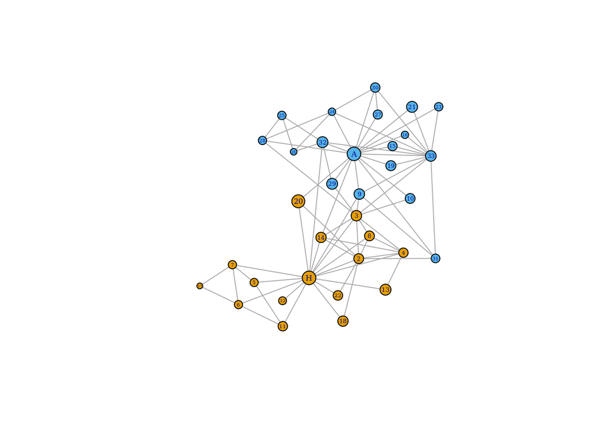

```r
plot(karate,
     vertex.size = closeness(karate)*1500,
     vertex.label.cex = closeness(karate)*70,
     layout = layout.davidson.harel)
```

Формально:
$$x'_i = \sum_{j} a_{ij}x_j$$
Если мы будем повторять это вычисление несколько раз, то мы сойдемся к одному из собственных векторов. Тогда можно определить центральность как
$$x_i = \frac{1}{\lambda} \sum_{j \in N(i)}x_t = \frac{1}{\lambda} \sum_{j \in G} a_{ij}x_j$$

```r
eigen_centrality(karate)$vector
```

```
##      Mr Hi    Actor 2    Actor 3    Actor 4    Actor 5    Actor 6    Actor 7
## 0.85787944 0.82876616 0.99036448 0.54536909 0.15291191 0.18519270 0.18250148
##    Actor 8    Actor 9   Actor 10   Actor 11   Actor 12   Actor 13   Actor 14
## 0.49006831 0.67825515 0.13788382 0.12588193 0.11866884 0.11499616 0.66050150
##   Actor 15   Actor 16   Actor 17   Actor 18   Actor 19   Actor 20   Actor 21
## 0.21845188 0.31067062 0.05086244 0.11732645 0.13429645 0.20164970 0.17234251
##   Actor 22   Actor 23   Actor 24   Actor 25   Actor 26   Actor 27   Actor 28
## 0.15554033 0.22248354 0.59886179 0.14020695 0.33667492 0.16102652 0.40561477
##   Actor 29   Actor 30   Actor 31   Actor 32   Actor 33     John A
## 0.23660019 0.37306834 0.43481077 0.57527665 0.91256318 1.00000000
```

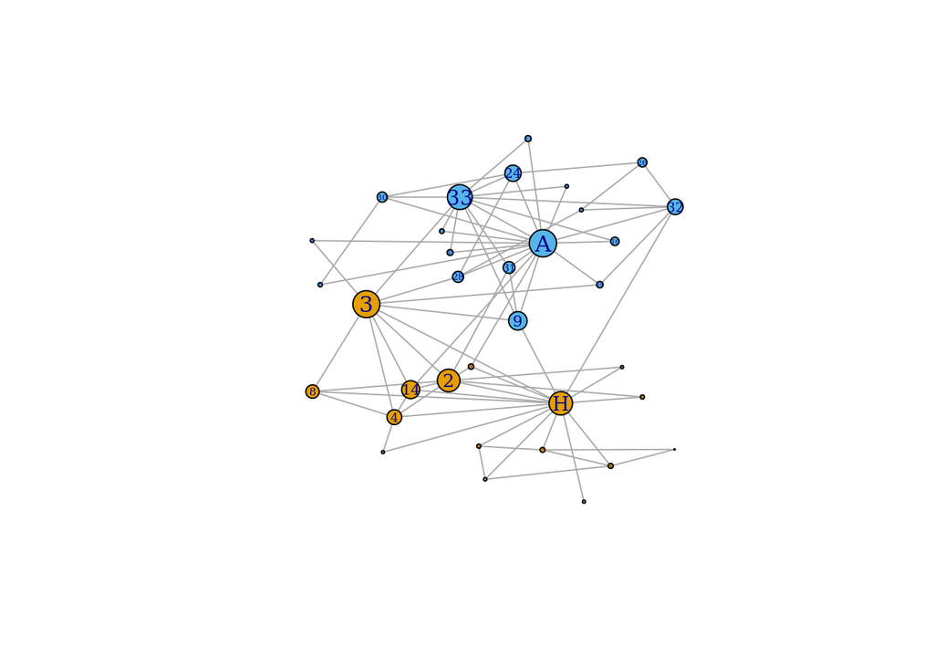

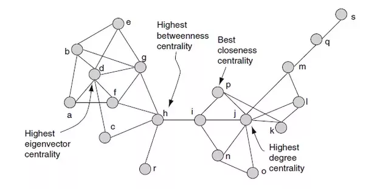

```r
plot(karate,
     vertex.size = eigen_centrality(karate)$vector*15,
     vertex.label.cex = eigen_centrality(karate)$vector,
     layout = layout.davidson.harel)
```

##### Как понять, что считать

- определите, что вам важно содержательно, какие вершины вы будете считать важными
- определите, какой мере центральности соответствует ваше понятие важности
- вычислите
- (а иногда полезно вычислить несколько и сравнить – например, вершина может быть важной сразу по нескольким характеристикам)

### Выявление сообществ (community detection)

Основная идея выделения сообществ – члены сообщества должны быть больше “похожи” (т.е. связаны) друг на друга, чем на участников других сообществ (другими словами, число связей между членами одного сообщества должно быть больше, чем число связей между сообществами).

Метод **edge betweenness**, так же известный как **Girvan–Newman algorithm**: иерархический метод, состоящий в последовательном удалении связей в порядке убывания показателей битвинности ребер (edge betweenness scores), то есть числа кратчайших путей, проходящих по рассматриваемому ребру. Другими словами, сначала ищется ребро, которое обладает большей битвинностью, т.е. является лучшим кандидатом на соединение сообществ между собой, потом следующее из оставшихся и т.д.

А в коде все просто:

```r
ebcommune <- edge.betweenness.community(karate)
membership(ebcommune) ## assigning nodes to communities
```

```
##    Mr Hi  Actor 2  Actor 3  Actor 4  Actor 5  Actor 6  Actor 7  Actor 8
##        1        1        2        1        3        3        3        1
##  Actor 9 Actor 10 Actor 11 Actor 12 Actor 13 Actor 14 Actor 15 Actor 16
##        4        2        3        1        1        2        4        4
## Actor 17 Actor 18 Actor 19 Actor 20 Actor 21 Actor 22 Actor 23 Actor 24
##        3        1        4        1        4        1        4        5
## Actor 25 Actor 26 Actor 27 Actor 28 Actor 29 Actor 30 Actor 31 Actor 32
##        5        5        6        5        2        6        4        4
## Actor 33   John A
##        4        4
```

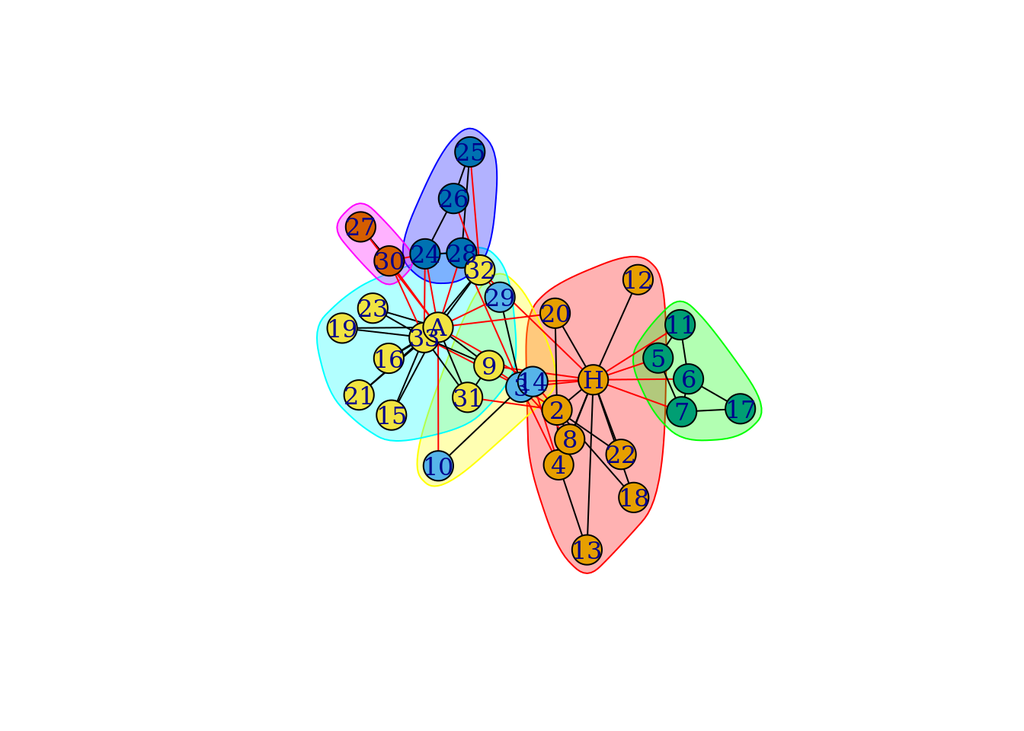

```r
plot(ebcommune, karate)
```

- Сколько групп получилось?

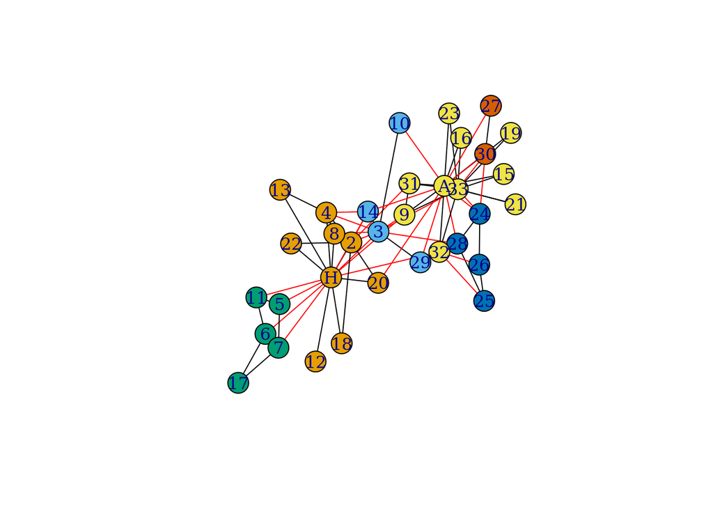

```r
plot(ebcommune, karate, mark.groups = NULL)
```

Качество разбиения можно оценить с помощью такого показателя, как модулярность. Модулярность равна доле рёбер от общего числа рёбер, которые попадают в данные группы минус ожидаемая доля рёбер, которые попали бы в те же группы, если бы они были распределены случайно. Значение модулярности лежит в интервале [-1,1]. Чем больше модулярность, тем лучше разбиение.

```r
modularity(ebcommune)
```

```
## [1] 0.345299
```

#### Другие алгоримы

- **Fast-Greedy**: иерархический подход. Первоначально каждая вершина представляет собой отдельное сообщество. Сообщества объединяются таким образом, чтобы это привело к наибольшему возрастанию модулярности. Останавливаемся, когда нет следующего шага, увеличивающего модулярность.

```r
fgcommune <- fastgreedy.community(karate)
membership(fgcommune) ## assigning nodes to communities
```

```
##    Mr Hi  Actor 2  Actor 3  Actor 4  Actor 5  Actor 6  Actor 7  Actor 8
##        2        2        2        2        3        3        3        2
##  Actor 9 Actor 10 Actor 11 Actor 12 Actor 13 Actor 14 Actor 15 Actor 16
##        1        1        3        2        2        2        1        1
## Actor 17 Actor 18 Actor 19 Actor 20 Actor 21 Actor 22 Actor 23 Actor 24
##        3        2        1        2        1        2        1        1
## Actor 25 Actor 26 Actor 27 Actor 28 Actor 29 Actor 30 Actor 31 Actor 32
##        1        1        1        1        1        1        1        1
## Actor 33   John A
##        1        1
```

```r
modularity(fgcommune)
```

```
## [1] 0.4345215
```

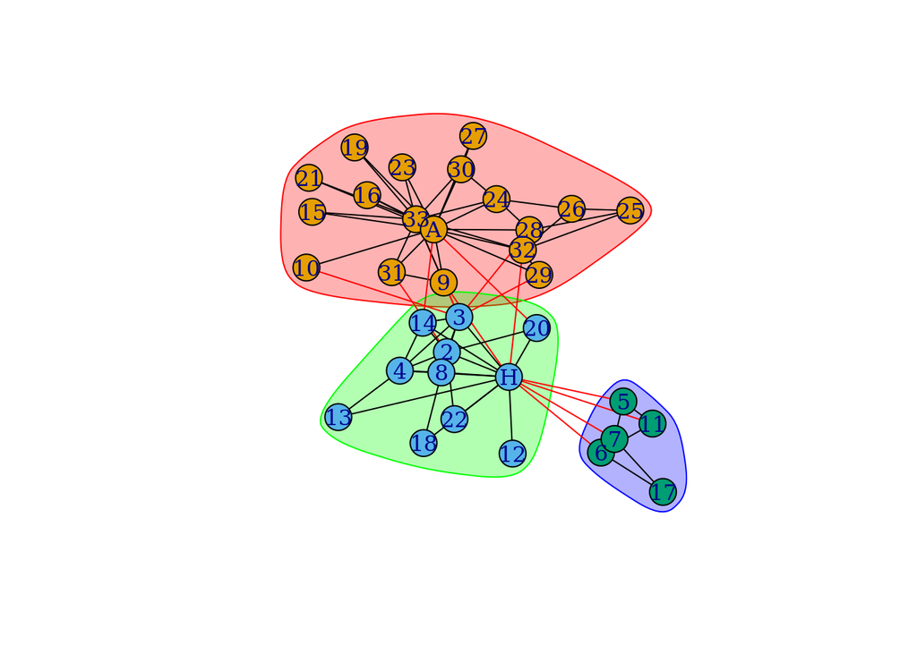

```r
plot(fgcommune, karate)
```

- **Walktrap**: Подход, основанный на случайных путях. Основная идея – если случайно “блуждать” по графу, то больше шансов, что ваш путь будет чаще оставаться внутри сообщества и только иногда выходить за его пределы.

```r
wtcommune <- walktrap.community(karate)
membership(wtcommune) ## assigning nodes to communities
```

```
##    Mr Hi  Actor 2  Actor 3  Actor 4  Actor 5  Actor 6  Actor 7  Actor 8
##        2        2        2        2        3        3        3        2
##  Actor 9 Actor 10 Actor 11 Actor 12 Actor 13 Actor 14 Actor 15 Actor 16
##        1        1        3        2        2        2        1        1
## Actor 17 Actor 18 Actor 19 Actor 20 Actor 21 Actor 22 Actor 23 Actor 24
##        3        2        1        2        1        2        1        4
## Actor 25 Actor 26 Actor 27 Actor 28 Actor 29 Actor 30 Actor 31 Actor 32
##        4        4        1        4        1        1        1        4
## Actor 33   John A
##        1        1
```

```r
modularity(wtcommune)
```

```
## [1] 0.440181
```

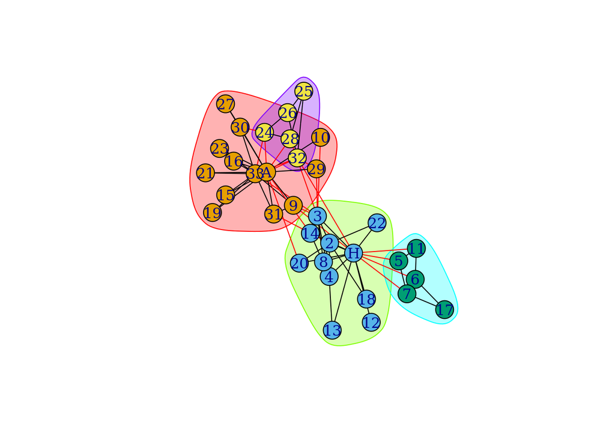

```r
plot(wtcommune, karate)
```

Другие алгоритмы в `igraph` (см. справку)

- label.propagation.community
- leading.eigenvector.community
- multilevel.community
- optimal.community
- spinglass.community
- infomap.community

> Важно! Разные алгоритмы могут приводить к разному разбиению. Т.е. разбиение на сообщества не дает идеальной, единственно правильной картины (получались ли у вас неожиданные разбиения в своей сети друзей?), а просто показывает один из вариантов, который уже дальше нужно анализировать содержательно

#### Какой алгоритм использовать

- Любой
- В любом случае это используется больше для выявления общих закономерностей, чем для четкого отнесения элементов к той или иной группе.
- Можно попробовать несколько и сравнить результаты по модулярности